# exploratory analysis

```r
library(readr)
library(lavaan)
library(semPlot)
library(dplyr)
library(tidyverse)
library(Hmisc)
```

#load data

```r
IRP<- read_csv("C:/Users/hanam/Desktop/IRP/IRP.csv")
head(IRP)
```

| ResponseId | consent sheet_Id | gender | IM1 | IM2 | IM3 | IM4 | IM5 | IM6 | IM7 | IM8 | IM9 | IM10 | IM11 | IM12 | IM13 | IM14 | IM15 | IM16 | IM17 | HC1 | HC2 | HC3 | HC4 | VC1 | VC2 | VC3 | VC4 | HI1 | HI2 | … |
| --- | --- | --- | --- | --- | --- | --- | --- | --- | --- | --- | --- | --- | --- | --- | --- | --- | --- | --- | --- | --- | --- | --- | --- | --- | --- | --- | --- | --- | --- | --- |
| R_2D630uAYeZU68Nu | F_11cnxcO2hEdklM9 | 2 | 1 | 0 | 1 | 1 | 1 | 1 | 1 | 1 | 1 | 0 | 1 | 0 | 1 | 0 | 1 | 0 | 1 | 7 | 7 | 6 | 6 | 8 | 6 | 7 | 7 | 8 | 8 | … |
| R_8yzv3hnHVM4IYAV | F_XoInUSCpYUzcGHv | 2 | 0 | 0 | 1 | 1 | 0 | 0 | 0 | 0 | 1 | 1 | 0 | 1 | 1 | 1 | 0 | 0 | 0 | 2 | 6 | 4 | 4 | 4 | 2 | 5 | 5 | 7 | 4 | … |
| R_2IEUifwyCjfzkdj | F_2tJWSVQ3q6BTJwx | 2 | 1 | 1 | 0 | 1 | 1 | 0 | 1 | 1 | 1 | 1 | 1 | 1 | 1 | 1 | 1 | 1 | 1 | 7 | 5 | 8 | 7 | 8 | 7 | 6 | 6 | 9 | 9 | … |
| R_1ggbsU1iMpi7MB3 | F_1r05aGMdLqQ7Cda | 2 | 1 | 1 | 1 | 0 | 1 | 0 | 0 | 1 | 0 | 1 | 0 | 1 | 1 | 1 | 0 | 0 | 0 | 6 | 6 | 6 | 5 | 6 | 6 | 6 | 7 | 5 | 4 | … |
| R_740eauvxfu6XC9r | F_2Tw2PtpWZ6zPsHE | 1 | 0 | 0 | 0 | 1 | 1 | 0 | 0 | 1 | 1 | 1 | 0 | 0 | 1 | 1 | 0 | 0 | 0 | 7 | 5 | 7 | 7 | 7 | 7 | 4 | 6 | 8 | 8 | … |
| R_5n8ubI5FNxGEb7r | F_1IQVmniCjQzUgh4 | 2 | 1 | 0 | 1 | 1 | 1 | 0 | 1 | 1 | 1 | 1 | 1 | 0 | 1 | 1 | 0 | 0 | 1 | 7 | 6 | 7 | 7 | 7 | 7 | 7 | 7 | 7 | 7 | … |

*Latent variable 1: Individualism* measured by the INDCOL (Triandis & Gelfand, 1998), this included 4 items on horizontal individualism and vertical individualism. Items were answered on a 9-point likert scale, 1 being completely disagree/ never, and 9 being completely agree/always. Vertical individualism acknowledges and respects hierarchical structures while valuing individual autonomy, whereas horizontal individualism emphasizes equality and cooperation while minimizing social hierarchies. These dimensions help in understanding cultural variations in the expression of individualistic values within societies. Both these dimensions will form our latent variable.

items for latent individualism include: HI1, HI2, HI3, HI4, VI1, VI2, VI3, VI4.

*Latent variable 2: Impression management* measured by the SDS-17 (Stöber, 2001), this included 17 items on a 2-point likert scale ‘true’ and false’. True was coded as 1 and false as 0, questions IM1, IM4, IM6, IM7, IM11, IM15, and IM17 were reverse keyed. The instrument was designed to measure impression management and self-deception, impression management can be understood as the deliberate effort to shape perceptions, behaviors, and expressions to convey a particular image or impression to others, often aligned with personal or situational objectives. It plays a significant role in social interactions, self-presentation, and how individuals are perceived in various contexts.

items for latent impression management include: IM1, IM2, IM3, IM4, IM5, IM6, IM7, IM8, IM9, IM10, IM11, IM12, IM13, IM14, IIM15, IM16, and IM17.

*Latent variable 3: Perfectionism* measured by the APS-R, (Slaney et al., 2001). This included 8 items on order, discrepancy, and high standards. Items were answered on a 6-point Likert scale, 1 being completely disagree abd 6 being completely agree. These dimensions align with the broader framework of perfectionism, emphasizing the tendencies related to setting high standards for oneself and others, along with concerns and anxieties surrounding mistakes or imperfections. The APS provides insights into different aspects of perfectionism.

Items for latent perfectionism include: P1, P2, P3, P4, P5, P6, P7, P8.

*Latent variable 4: Life satisfaction* measured by the SWLS (Diener et al., 1985). This included 5 items on a 7-point likert scale. 1 being completely disagree and 7 being completely agree. Life satisfaction refers to an individual’s overall evaluation or subjective judgment of their life as a whole. It encompasses an individual’s cognitive assessment and emotional appraisal of various domains of their life.

Items for latent life satisfaction: LS1, LS2, LS3, LS4, LS5.

#normalization

```r
cols_to_normalize <- 4:49
IRP <- IRP %>%
  mutate_at(cols_to_normalize, scale)
```

#measurement model

```r
measurement.model <- "
impression_management=~ 1*IM1 + IM2 + IM3 + IM4 + IM5 + IM6 + IM7 + IM8 + IM9 + IM10 + IM11 + IM12 + IM13 + IM14 + IM15 + IM16 + IM17
individualism=~ 1*HI1 + HI2 + HI3 + HI4 + VI1 + VI2 + VI3 + VI4
perfectionism=~ 1*P1 + P2 + P3 + P4 + P5 + P6 + P7 + P8
life_satisfaction=~ 1*LS1 + LS2 + LS3 + LS4 + LS5"
```

Fit indexes and model parameters

```r
measurement.model.fit <- cfa(measurement.model, data=IRP)
summary(measurement.model.fit, fit.measures=TRUE, standardized=TRUE)
```

```
lavaan 0.6.16 did NOT end normally after 2451 iterations
** WARNING ** Estimates below are most likely unreliable

  Estimator                                         ML
  Optimization method                           NLMINB
  Number of model parameters                        82

  Number of observations                            62


Parameter Estimates:

  Standard errors                             Standard
  Information                                 Expected
  Information saturated (h1) model          Structured

Latent Variables:
                           Estimate  Std.Err  z-value  P(>|z|)   Std.lv  Std.all
  impression_management =~
    IM1                       1.000                              20.778   20.850
    IM2                      -0.000       NA                     -0.005   -0.005
    IM3                      -0.000       NA                     -0.004   -0.004
    IM4                      -0.000       NA                     -0.004   -0.004
    IM5                       0.000       NA                      0.004    0.004
    IM6                      -0.000       NA                     -0.003   -0.003
    IM7                       0.000       NA                      0.000    0.000
    IM8                       0.000       NA                      0.004    0.004
    IM9                      -0.000       NA                     -0.005   -0.005
    IM10                     -0.000       NA                     -0.008   -0.008
    IM11                      0.001       NA                      0.012    0.012
    IM12                      0.000       NA                      0.000    0.000
    IM13                      0.001       NA                      0.011    0.011
    IM14                     -0.001       NA                     -0.011   -0.012
    IM15                      0.000       NA                      0.003    0.003
    IM16                     -0.001       NA                     -0.020   -0.020
    IM17                      0.000       NA                      0.006    0.006
  individualism =~
    HI1                       1.000                               1.041    1.049
    HI2                       0.331       NA                      0.345    0.348
    HI3                       0.118       NA                      0.122    0.123
```

[output cut: 62 more lines]

```
   .P3                0.486       NA                      0.486    0.494
   .P4                0.828       NA                      0.828    0.842
   .P5                0.968       NA                      0.968    0.984
   .P6                0.943       NA                      0.943    0.959
   .P7                0.776       NA                      0.776    0.789
   .P8                0.959       NA                      0.959    0.975
   .LS1               0.984       NA                      0.984    1.000
   .LS2               0.984       NA                      0.984    1.000
   .LS3            -143.121       NA                   -143.121 -144.787
   .LS4               0.984       NA                      0.984    1.000
   .LS5               0.984       NA                      0.984    1.000
    imprssn_mngmnt  431.712       NA                      1.000    1.000
    individualism     1.084       NA                      1.000    1.000
    perfectionism     0.139       NA                      1.000    1.000
    life_satisfctn    0.000       NA                      1.000    1.000
```

#error-free correlations

```r
IRP <- IRP %>%
  mutate(im = (IM1 + IM2 + IM3 + IM4 + IM5 + IM6 + IM7 + IM8 + IM9 + IM10 + IM11 + IM12 + IM13 + IM14 + IM15 + IM16 + IM17)/17)
IRP <- IRP %>%
  mutate(ind = (HI1 + HI2 + HI3 + HI4 + VI1 + VI2 + VI3 + VI4)/8)
IRP <- IRP %>%
  mutate(perf = (P1 + P2 + P3 + P4 + P5 + P6 + P7 + P8)/8)
IRP <- IRP %>%
  mutate(ls = (LS1 + LS2 + LS3 + LS4 + LS5)/5)
rcorr(as.matrix(IRP[,c("im","ind", "perf", "ls")], type="pearson"))
```

```
       im  ind perf   ls
im   1.00 0.01 0.09 0.28
ind  0.01 1.00 0.31 0.25
perf 0.09 0.31 1.00 0.05
ls   0.28 0.25 0.05 1.00

n= 62


P
     im     ind    perf   ls
im          0.9379 0.5076 0.0285
ind  0.9379        0.0155 0.0456
perf 0.5076 0.0155        0.7150
ls   0.0285 0.0456 0.7150
```

#composite reliability

```r
# save standardised factor loadings in object s1
sl <- standardizedSolution(measurement.model.fit)
# extract from s1 standardised estimates (est.std) form only parent conditional regard
sl <- sl$est.std[sl$lhs == "individualism"]

# calculate the residual variances
re <- 1 - sl^2

# calculate the composite reliability
sum(sl)^2 / (sum(sl)^2 + sum(re))
```

```
[1] 0.5490385
```

```r
# save standardised factor loadings in object s1
sl <- standardizedSolution(measurement.model.fit)
# extract from s1 standardised estimates (est.std) form only parent conditional regard
sl <- sl$est.std[sl$lhs == "impression_management"]

# calculate the residual variances
re <- 1 - sl^2

# calculate the composite reliability
sum(sl)^2 / (sum(sl)^2 + sum(re))
```

```
[1] 7.630444
```

```r
# save standardised factor loadings in object s1
sl <- standardizedSolution(measurement.model.fit)
# extract from s1 standardised estimates (est.std) form only parent conditional regard
sl <- sl$est.std[sl$lhs == "perfectionism"]

# calculate the residual variances
re <- 1 - sl^2

# calculate the composite reliability
sum(sl)^2 / (sum(sl)^2 + sum(re))
```

```
[1] 0.6155523
```

```r
# save standardised factor loadings in object s1
sl <- standardizedSolution(measurement.model.fit)
# extract from s1 standardised estimates (est.std) form only life satisfaction
sl <- sl$est.std[sl$lhs == "life satisfaction"]

# calculate the residual variances
re <- 1 - sl^2

# calculate the composite reliability
sum(sl)^2 / (sum(sl)^2 + sum(re))
```

```
[1] NaN
```

#visualizing CFA

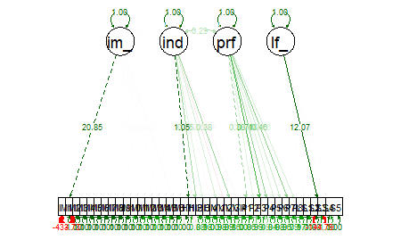

```r
semPaths(measurement.model.fit, "std")
```

##Testing the Full Latent Variable Structural Equation Model (SEM)

Testing the effect of individualism on life satisfaction, to further substantiate/ clarify the relationship between collectivism and life satisfaction

```r
sem.model <- "
# measurement portion of model
impression_management =~ 1*IM1 + IM2 + IM3 + IM4 + IM5 + IM6 + IM7 + IM8 + IM9 + IM10 + IM11 + IM12 + IM13 + IM14 + IM15 + IM16 + IM17
individualism =~ 1*HI1 + HI2 + HI3 + HI4 + VI1 + VI2 + VI3 + VI4
perfectionism =~ 1*P1 + P2 + P3 + P4 + P5 + P6 + P7 + P8
life_satisfaction =~ 1*LS1 + LS2 + LS3 + LS4 + LS5
# structural portion of model
perfectionism ~ a1*individualism
impression_management ~ a2*individualism
life_satisfaction ~ b1*perfectionism
life_satisfaction~ b2*impression_management

#the indirect effects
a1b1 := a1*b1
a2b2 := a2*b2"
```

fitting model

```r
sem.model.fit <- sem(sem.model, data=IRP, se = "bootstrap", bootstrap = 100)
summary(sem.model.fit, fit.measures=TRUE, standardized=TRUE)
```

```
lavaan 0.6.16 did NOT end normally after 3015 iterations
** WARNING ** Estimates below are most likely unreliable

  Estimator                                         ML
  Optimization method                           NLMINB
  Number of model parameters                        80

  Number of observations                            62


Parameter Estimates:

  Standard errors                            Bootstrap
  Number of requested bootstrap draws              100
  Number of successful bootstrap draws               0

Latent Variables:
                           Estimate  Std.Err  z-value  P(>|z|)   Std.lv  Std.all
  impression_management =~
    IM1                       1.000                              15.909   16.052
    IM2                      -0.000       NA                     -0.006   -0.006
    IM3                      -0.000       NA                     -0.006   -0.006
    IM4                      -0.000       NA                     -0.004   -0.004
    IM5                       0.000       NA                      0.005    0.005
    IM6                      -0.000       NA                     -0.003   -0.003
    IM7                       0.000       NA                      0.002    0.002
    IM8                       0.000       NA                      0.006    0.006
    IM9                      -0.000       NA                     -0.007   -0.007
    IM10                     -0.001       NA                     -0.010   -0.010
    IM11                      0.001       NA                      0.016    0.016
    IM12                     -0.000       NA                     -0.000   -0.000
    IM13                      0.001       NA                      0.014    0.015
    IM14                     -0.001       NA                     -0.014   -0.014
    IM15                      0.000       NA                      0.003    0.003
    IM16                     -0.002       NA                     -0.027   -0.027
    IM17                      0.000       NA                      0.007    0.007
  individualism =~
    HI1                       1.000                               1.194    1.204
    HI2                       0.249       NA                      0.298    0.300
    HI3                       0.072       NA                      0.086    0.087
```

[output cut: 65 more lines]

```
   .P8                0.962       NA                      0.962    0.978
   .LS1               0.984       NA                      0.984    1.000
   .LS2               0.984       NA                      0.984    1.000
   .LS3            -201.301       NA                   -201.301 -201.858
   .LS4               0.984       NA                      0.984    1.000
   .LS5               0.984       NA                      0.984    1.000
   .imprssn_mngmnt  253.064       NA                      1.000    1.000
    individualism     1.425       NA                      1.000    1.000
   .perfectionism     0.131       NA                      0.938    0.938
   .life_satisfctn    0.000       NA                      1.000    1.000

Defined Parameters:
                   Estimate  Std.Err  z-value  P(>|z|)   Std.lv  Std.all
    a1b1              0.000                               0.001    0.001
    a2b2              0.000                               0.000    0.000
```

```r
parameterestimates(sem.model.fit, boot.ci.type = "perc", standardized = TRUE)
```

```
Error in parameterestimates(sem.model.fit, boot.ci.type = "perc", standardized = TRUE) :
  !is.null(BOOT) is not TRUE
```

```r
lavInspect(sem.model.fit, what = "rsquare")
```

```
                  IM1                   IM2                   IM3                   IM4                   IM5
                   NA                 0.000                 0.000                 0.000                 0.000
                  IM6                   IM7                   IM8                   IM9                  IM10
                0.000                 0.000                 0.000                 0.000                 0.000
                 IM11                  IM12                  IM13                  IM14                  IM15
                0.000                 0.000                 0.000                 0.000                 0.000
                 IM16                  IM17                   HI1                   HI2                   HI3
                0.001                 0.000                    NA                 0.090                 0.008
                  HI4                   VI1                   VI2                   VI3                   VI4
                0.001                 0.014                 0.003                 0.119                 0.001
                   P1                    P2                    P3                    P4                    P5
                0.142                 0.013                 0.571                 0.137                 0.007
                   P6                    P7                    P8                   LS1                   LS2
                0.035                 0.197                 0.022                 0.000                 0.000
                  LS3                   LS4                   LS5 impression_management         perfectionism
                   NA                 0.000                 0.000                 0.000                 0.062
    life_satisfaction
                0.000
```

```r
semPaths(sem.model.fit, "std")
```

```
Error in parameterEstimates(object, standardized = TRUE) :
  !is.null(BOOT) is not TRUE
```

#Independent t-test- observing gender differences

```r
library(mosaic)
library(sjlabelled)
library(fastDummies)
library(supernova)
library(readr)
library(rstatix)
library(Hmisc)
library(ggpubr)
```

*Research Question* - Do levels of impression management differ between males and females?

*Null Hypothesis* - The difference between male and female levels of impression management will be zero.

##descriptives

```r
df_gender <-
IRP %>%
  mutate(
   gender= case_when(
      gender == 1  ~ "male",
      gender == 2 ~ "female"
    )
 )
df_gender
```

| ResponseId | consent sheet_Id | gender | IM1 | IM2 | IM3 | IM4 | IM5 | IM6 | IM7 | IM8 | IM9 | IM10 | IM11 | IM12 | IM13 | IM14 | IM15 | IM16 | IM17 | HC1 | HC2 | HC3 | HC4 | VC1 | VC2 | VC3 | VC4 | HI1 | HI2 | … |
| --- | --- | --- | --- | --- | --- | --- | --- | --- | --- | --- | --- | --- | --- | --- | --- | --- | --- | --- | --- | --- | --- | --- | --- | --- | --- | --- | --- | --- | --- | --- |
| R_2D630uAYeZU68Nu | F_11cnxcO2hEdklM9 | female | 1.0244327 | -0.8711981 | 1.0581008 | 0.9298462 | 0.8429552 | 1.3374813 | 0.9919027 | 0.6344231 | 0.9919027 | -1.1293309 | 0.8711981 | -1.093024 | 0.815339 | -0.9298462 | 1.0244327 | -1.0244327 | 0.900137 | 0.75356388 | 0.6680879 | 0.5459211 | 0.2335845 | 1.2284409 | 0.2360509 | 0.73380352 | 0.6248755 | 1.0035159 | 1.146775513 | … |
| R_8yzv3hnHVM4IYAV | F_XoInUSCpYUzcGHv | female | -0.9604057 | -0.8711981 | 1.0581008 | 0.9298462 | -1.1671687 | -0.7356147 | -0.9919027 | -1.5508120 | 0.9919027 | 0.8711981 | -1.1293309 | 0.900137 | 0.815339 | 1.0581008 | -0.9604057 | -1.0244327 | -1.093024 | -1.16122958 | 0.2226960 | -0.3002566 | -0.7007535 | -0.5742416 | -1.3900773 | -0.07862181 | -0.2082918 | 0.6046827 | -0.390523553 | … |
| R_2IEUifwyCjfzkdj | F_2tJWSVQ3q6BTJwx | female | 1.0244327 | 1.1293309 | -0.9298462 | 0.9298462 | 0.8429552 | -0.7356147 | 0.9919027 | 0.6344231 | 0.9919027 | 0.8711981 | 0.8711981 | 0.900137 | 0.815339 | 1.0581008 | 1.0244327 | 0.9604057 | 0.900137 | 0.75356388 | -0.2226960 | 1.3920988 | 0.7007535 | 1.2284409 | 0.6425829 | 0.32759086 | 0.2082918 | 1.4023492 | 1.531100280 | … |
| R_1ggbsU1iMpi7MB3 | F_1r05aGMdLqQ7Cda | female | 1.0244327 | 1.1293309 | 1.0581008 | -1.0581008 | 0.8429552 | -0.7356147 | -0.9919027 | 0.6344231 | -0.9919027 | 0.8711981 | -1.1293309 | 0.900137 | 0.815339 | 1.0581008 | -0.9604057 | -1.0244327 | -1.093024 | 0.37060519 | 0.2226960 | 0.5459211 | -0.2335845 | 0.3270997 | 0.2360509 | 0.32759086 | 0.6248755 | -0.1929838 | -0.390523553 | … |
| R_740eauvxfu6XC9r | F_2Tw2PtpWZ6zPsHE | male | -0.9604057 | -0.8711981 | -0.9298462 | 0.9298462 | 0.8429552 | -0.7356147 | -0.9919027 | 0.6344231 | 0.9919027 | 0.8711981 | -1.1293309 | -1.093024 | 0.815339 | 1.0581008 | -0.9604057 | -1.0244327 | -1.093024 | 0.75356388 | -0.2226960 | 0.9690099 | 0.7007535 | 0.7777703 | 0.6425829 | -0.48483447 | 0.2082918 | 1.0035159 | 1.146775513 | … |
| R_5n8ubI5FNxGEb7r | F_1IQVmniCjQzUgh4 | female | 1.0244327 | -0.8711981 | 1.0581008 | 0.9298462 | 0.8429552 | -0.7356147 | 0.9919027 | 0.6344231 | 0.9919027 | 0.8711981 | 0.8711981 | -1.093024 | 0.815339 | 1.0581008 | -0.9604057 | -1.0244327 | 0.900137 | 0.75356388 | 0.2226960 | 0.9690099 | 0.7007535 | 0.7777703 | 0.6425829 | 0.73380352 | 0.6248755 | 0.6046827 | 0.762450747 | … |
| R_78hVv1cqle405jj | F_2YAt8XrwMrr9Dv5 | female | 1.0244327 | -0.8711981 | -0.9298462 | 0.9298462 | 0.8429552 | -0.7356147 | -0.9919027 | 0.6344231 | 0.9919027 | -1.1293309 | 0.8711981 | 0.900137 | 0.815339 | -0.9298462 | -0.9604057 | -1.0244327 | -1.093024 | 1.13652257 | 1.1134799 | -0.3002566 | 0.2335845 | -1.9262535 | -0.9835453 | -1.29725979 | 0.6248755 | 0.6046827 | -0.774848320 | … |
| R_2Nf7lzGjfVdjJ9H | F_3I3l39hvzP2Bizd | male | 1.0244327 | -0.8711981 | -0.9298462 | 0.9298462 | 0.8429552 | 1.3374813 | 0.9919027 | -1.5508120 | -0.9919027 | 0.8711981 | 0.8711981 | -1.093024 | -1.206702 | -0.9298462 | -0.9604057 | 0.9604057 | 0.900137 | -0.77827089 | 0.2226960 | -0.7233454 | -0.2335845 | 0.3270997 | 0.6425829 | 0.32759086 | -0.2082918 | 0.6046827 | 0.378125980 | … |
| R_1neIBpWiE8HiKNi | F_22VTtJHddkmJiSI | female | -0.9604057 | -0.8711981 | 1.0581008 | -1.0581008 | 0.8429552 | 1.3374813 | 0.9919027 | -1.5508120 | 0.9919027 | 0.8711981 | -1.1293309 | 0.900137 | -1.206702 | 1.0581008 | 1.0244327 | -1.0244327 | 0.900137 | 0.75356388 | 1.5588718 | 0.9690099 | 0.7007535 | 0.7777703 | 1.0491150 | 0.32759086 | 1.0414592 | 1.0035159 | 1.146775513 | … |
| R_70oSeXAqJJPKmqD | F_pQpBP8mj5jWAYUx | male | -0.9604057 | 1.1293309 | -0.9298462 | 0.9298462 | -1.1671687 | -0.7356147 | -0.9919027 | 0.6344231 | 0.9919027 | -1.1293309 | 0.8711981 | 0.900137 | 0.815339 | 1.0581008 | -0.9604057 | 0.9604057 | -1.093024 | 0.75356388 | 0.2226960 | 0.1228322 | 0.7007535 | 0.3270997 | 0.6425829 | -0.48483447 | 1.0414592 | 1.4023492 | 0.378125980 | … |

[output cut: 52 more lines]

#setting up linear model

```r
favstats(~im, gender, data=df_gender)
```

| gender | min | Q1 | median | Q3 | max | mean | sd | n | missing |
| --- | --- | --- | --- | --- | --- | --- | --- | --- | --- |
| female | -0.4623638 | -0.1084483 | 0.02171039 | 0.25411521 | 0.7223695 | 0.04528801 | 0.2883705 | 38 | 0 |
| male | -0.5681932 | -0.2283671 | -0.09405934 | 0.05155988 | 0.4887370 | -0.07170601 | 0.2394195 | 24 | 0 |

```r
df_gender$dummy <- ifelse(df_gender$gender == c("female"), 1, 0)
df_gender
```

| ResponseId | consent sheet_Id | gender | IM1 | IM2 | IM3 | IM4 | IM5 | IM6 | IM7 | IM8 | IM9 | IM10 | IM11 | IM12 | IM13 | IM14 | IM15 | IM16 | IM17 | HC1 | HC2 | HC3 | HC4 | VC1 | VC2 | VC3 | VC4 | HI1 | HI2 | … |
| --- | --- | --- | --- | --- | --- | --- | --- | --- | --- | --- | --- | --- | --- | --- | --- | --- | --- | --- | --- | --- | --- | --- | --- | --- | --- | --- | --- | --- | --- | --- |
| R_2D630uAYeZU68Nu | F_11cnxcO2hEdklM9 | female | 1.0244327 | -0.8711981 | 1.0581008 | 0.9298462 | 0.8429552 | 1.3374813 | 0.9919027 | 0.6344231 | 0.9919027 | -1.1293309 | 0.8711981 | -1.093024 | 0.815339 | -0.9298462 | 1.0244327 | -1.0244327 | 0.900137 | 0.75356388 | 0.6680879 | 0.5459211 | 0.2335845 | 1.2284409 | 0.2360509 | 0.73380352 | 0.6248755 | 1.0035159 | 1.146775513 | … |
| R_8yzv3hnHVM4IYAV | F_XoInUSCpYUzcGHv | female | -0.9604057 | -0.8711981 | 1.0581008 | 0.9298462 | -1.1671687 | -0.7356147 | -0.9919027 | -1.5508120 | 0.9919027 | 0.8711981 | -1.1293309 | 0.900137 | 0.815339 | 1.0581008 | -0.9604057 | -1.0244327 | -1.093024 | -1.16122958 | 0.2226960 | -0.3002566 | -0.7007535 | -0.5742416 | -1.3900773 | -0.07862181 | -0.2082918 | 0.6046827 | -0.390523553 | … |
| R_2IEUifwyCjfzkdj | F_2tJWSVQ3q6BTJwx | female | 1.0244327 | 1.1293309 | -0.9298462 | 0.9298462 | 0.8429552 | -0.7356147 | 0.9919027 | 0.6344231 | 0.9919027 | 0.8711981 | 0.8711981 | 0.900137 | 0.815339 | 1.0581008 | 1.0244327 | 0.9604057 | 0.900137 | 0.75356388 | -0.2226960 | 1.3920988 | 0.7007535 | 1.2284409 | 0.6425829 | 0.32759086 | 0.2082918 | 1.4023492 | 1.531100280 | … |
| R_1ggbsU1iMpi7MB3 | F_1r05aGMdLqQ7Cda | female | 1.0244327 | 1.1293309 | 1.0581008 | -1.0581008 | 0.8429552 | -0.7356147 | -0.9919027 | 0.6344231 | -0.9919027 | 0.8711981 | -1.1293309 | 0.900137 | 0.815339 | 1.0581008 | -0.9604057 | -1.0244327 | -1.093024 | 0.37060519 | 0.2226960 | 0.5459211 | -0.2335845 | 0.3270997 | 0.2360509 | 0.32759086 | 0.6248755 | -0.1929838 | -0.390523553 | … |
| R_740eauvxfu6XC9r | F_2Tw2PtpWZ6zPsHE | male | -0.9604057 | -0.8711981 | -0.9298462 | 0.9298462 | 0.8429552 | -0.7356147 | -0.9919027 | 0.6344231 | 0.9919027 | 0.8711981 | -1.1293309 | -1.093024 | 0.815339 | 1.0581008 | -0.9604057 | -1.0244327 | -1.093024 | 0.75356388 | -0.2226960 | 0.9690099 | 0.7007535 | 0.7777703 | 0.6425829 | -0.48483447 | 0.2082918 | 1.0035159 | 1.146775513 | … |
| R_5n8ubI5FNxGEb7r | F_1IQVmniCjQzUgh4 | female | 1.0244327 | -0.8711981 | 1.0581008 | 0.9298462 | 0.8429552 | -0.7356147 | 0.9919027 | 0.6344231 | 0.9919027 | 0.8711981 | 0.8711981 | -1.093024 | 0.815339 | 1.0581008 | -0.9604057 | -1.0244327 | 0.900137 | 0.75356388 | 0.2226960 | 0.9690099 | 0.7007535 | 0.7777703 | 0.6425829 | 0.73380352 | 0.6248755 | 0.6046827 | 0.762450747 | … |
| R_78hVv1cqle405jj | F_2YAt8XrwMrr9Dv5 | female | 1.0244327 | -0.8711981 | -0.9298462 | 0.9298462 | 0.8429552 | -0.7356147 | -0.9919027 | 0.6344231 | 0.9919027 | -1.1293309 | 0.8711981 | 0.900137 | 0.815339 | -0.9298462 | -0.9604057 | -1.0244327 | -1.093024 | 1.13652257 | 1.1134799 | -0.3002566 | 0.2335845 | -1.9262535 | -0.9835453 | -1.29725979 | 0.6248755 | 0.6046827 | -0.774848320 | … |
| R_2Nf7lzGjfVdjJ9H | F_3I3l39hvzP2Bizd | male | 1.0244327 | -0.8711981 | -0.9298462 | 0.9298462 | 0.8429552 | 1.3374813 | 0.9919027 | -1.5508120 | -0.9919027 | 0.8711981 | 0.8711981 | -1.093024 | -1.206702 | -0.9298462 | -0.9604057 | 0.9604057 | 0.900137 | -0.77827089 | 0.2226960 | -0.7233454 | -0.2335845 | 0.3270997 | 0.6425829 | 0.32759086 | -0.2082918 | 0.6046827 | 0.378125980 | … |
| R_1neIBpWiE8HiKNi | F_22VTtJHddkmJiSI | female | -0.9604057 | -0.8711981 | 1.0581008 | -1.0581008 | 0.8429552 | 1.3374813 | 0.9919027 | -1.5508120 | 0.9919027 | 0.8711981 | -1.1293309 | 0.900137 | -1.206702 | 1.0581008 | 1.0244327 | -1.0244327 | 0.900137 | 0.75356388 | 1.5588718 | 0.9690099 | 0.7007535 | 0.7777703 | 1.0491150 | 0.32759086 | 1.0414592 | 1.0035159 | 1.146775513 | … |
| R_70oSeXAqJJPKmqD | F_pQpBP8mj5jWAYUx | male | -0.9604057 | 1.1293309 | -0.9298462 | 0.9298462 | -1.1671687 | -0.7356147 | -0.9919027 | 0.6344231 | 0.9919027 | -1.1293309 | 0.8711981 | 0.900137 | 0.815339 | 1.0581008 | -0.9604057 | 0.9604057 | -1.093024 | 0.75356388 | 0.2226960 | 0.1228322 | 0.7007535 | 0.3270997 | 0.6425829 | -0.48483447 | 1.0414592 | 1.4023492 | 0.378125980 | … |

[output cut: 52 more lines]

#partitioning variance

```r
gender.model <- lm(im ~ 1 + dummy, data=df_gender)

summary(gender.model)
```

```
Call:
lm(formula = im ~ 1 + dummy, data = df_gender)

Residuals:
     Min       1Q   Median       3Q      Max
-0.50765 -0.15579 -0.02292  0.20807  0.67708

Coefficients:
            Estimate Std. Error t value Pr(>|t|)
(Intercept) -0.07171    0.05525  -1.298    0.199
dummy        0.11699    0.07057   1.658    0.103

Residual standard error: 0.2707 on 60 degrees of freedom
Multiple R-squared:  0.0438,    Adjusted R-squared:  0.02787
F-statistic: 2.749 on 1 and 60 DF,  p-value: 0.1026
```

```r
library(supernova)
supernova(gender.model)
```

```
 Analysis of Variance Table (Type III SS)
 Model: im ~ 1 + dummy

                            SS df    MS     F   PRE     p
 ----- --------------- | ----- -- ----- ----- ----- -----
 Model (error reduced) | 0.201  1 0.201 2.749 .0438 .1026
 Error (from model)    | 4.395 60 0.073
 ----- --------------- | ----- -- ----- ----- ----- -----
 Total (empty model)   | 4.597 61 0.075
```

#effect size

```r
t.test(df_gender$im ~ df_gender$dummy, var.equal=TRUE)
```

```
    Two Sample t-test

data:  df_gender$im by df_gender$dummy
t = -1.6579, df = 60, p-value = 0.1026
alternative hypothesis: true difference in means between group 0 and group 1 is not equal to 0
95 percent confidence interval:
 -0.25815290  0.02416487
sample estimates:
mean in group 0 mean in group 1
    -0.07170601      0.04528801
```

```r
df_gender %>%
cohens_d(im ~ gender)
```

|  | .y. | group1 | group2 | effsize | n1 | n2 | magnitude |
| --- | --- | --- | --- | --- | --- | --- | --- |
| 1 | im | female | male | 0.4414409 | 38 | 24 | small |